# Proyecto vivienda

Gonzalo Terry

2022-12-21

## R Markdown

Comenzando instalando los paquetes que se van a utilizar, en este proyecto se va a utilizar el paquete “tidyverse”.

```r
install.packages("tidyverse")
library("tidyverse")
```

Se procede también a leer el archivo “.csv” de los datos

```r
ventas <- read_csv("spain_v_ventas_america.csv")
```

A continuación se va a estudiar la relación entre varias variables de un conjunto de datos público sobre la venta de vivienda en España

## Relación entre el precio de la vivienda por comunidades y la renta per cápita

Primero de todo se va a crear una nueva tabla con los datos que nos interesan, que en este caso son las provincias, su precio medio de vivienda, y su renta per cápita.

```r
tabla1 <- ventas %>%
  group_by(loc_zone) %>%
  summarize(renta_media = mean(renta_media_prov), precio_medio = mean(price))

tabla1
```

```
## # A tibble: 21 × 3
##    loc_zone    renta_media precio_medio
##    <chr>             <dbl>        <dbl>
##  1 A Coruña          21898      182104.
##  2 Álava             35175      242635.
##  3 Albacete          18113      126484.
##  4 Alicante          17405      172310.
##  5 Barcelona         26531      206795.
##  6 Cádiz             16916      102070.
##  7 Ciudad Real       18214       92415.
##  8 Girona            26722      247847.
##  9 Guipúzcoa         31442      351448.
## 10 Huelva            17959      123584.
## # … with 11 more rows
```

A continuación vamos a realizar la representación gráfica. Vamos a realizar un gráfico de dispersión colocando en el eje x al precio medio de la vivienda por provincia, y en el eje y la renta per cápita de la misma provincia.

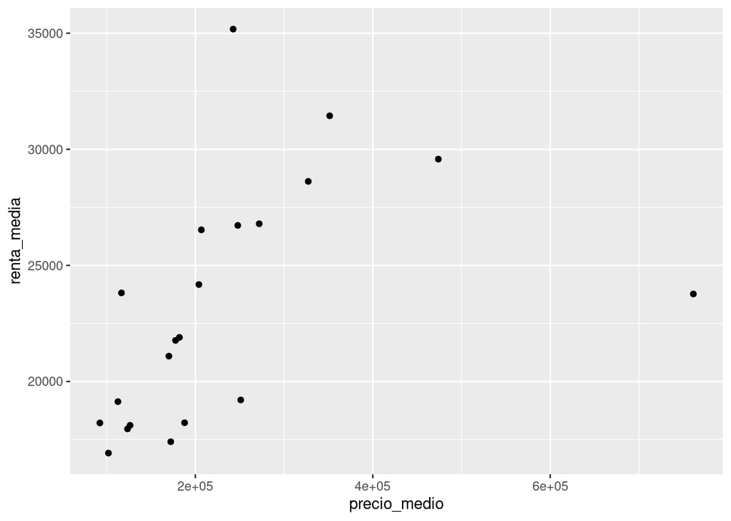

```r
ggplot(data = tabla1, aes(x = precio_medio, y = renta_media)) + geom_point()
```

A simple vista podemos intuir que los puntos siguen una posible tendencia lineal, vamos a calcular la correlación estadística.

```r
tabla1 %>%
  summarize(correlacion = cor(precio_medio, renta_media))
```

```
## # A tibble: 1 × 1
##   correlacion
##         <dbl>
## 1       0.465
```

Obtenemos una correlación de 0.465, no es extremadamente fuerte, pero en la tabla vemos que hay un precio medio de vivienda que se aleja de la tendencia, este es el punto del precio medio de vivienda en las Islas Baleares, ya que hay en proporción mas casa en venta de alta gama y lujosas comparado con el resto de las provincias. \ \ Vamos a quitar este punto y realizar los mismo pasos que antes. \ \ Empezamos por definir una nueva tabla, quitando la fila de las Islas Baleares.

```r
tabla2 <- tabla1[-11,]
tabla2
```

```
## # A tibble: 20 × 3
##    loc_zone               renta_media precio_medio
##    <chr>                        <dbl>        <dbl>
##  1 A Coruña                     21898      182104.
##  2 Álava                        35175      242635.
##  3 Albacete                     18113      126484.
##  4 Alicante                     17405      172310.
##  5 Barcelona                    26531      206795.
##  6 Cádiz                        16916      102070.
##  7 Ciudad Real                  18214       92415.
##  8 Girona                       26722      247847.
##  9 Guipúzcoa                    31442      351448.
## 10 Huelva                       17959      123584.
## 11 Madrid                       29576      473896.
## 12 Santa Cruz de Tenerife       19205      251180.
## 13 Segovia                      21769      177672.
## 14 Sevilla                      18223      187903.
## 15 Soria                        23816      116754.
## 16 Tarragona                    26792      271986.
## 17 Valencia                     21091      170199.
## 18 Valladolid                   24176      204000.
## 19 Vizcaya                      28618      327294.
## 20 Zamora                       19132      112762.
```

Ahora calculamos de nuevo la correlacion.

```r
tabla2 %>%
  summarize(correlacion = cor(precio_medio, renta_media))
```

```
## # A tibble: 1 × 1
##   correlacion
##         <dbl>
## 1       0.726
```

Ahora se obtiene una correlación estadística mucho mas alta, de aproximadamente 0.726.

Con estos resultamos no podemos afirmar que haya causalidad entre la renta media de una provincia y el precio medio de la vivienda en dicha provincia.

Lo que podemos afirmar con esta moderada correlación es que si que hay una tendencia entre estas dos variables, por lo menos, en el mercado español, ya que esta tendencia podría variar dependiendo del modelo económico de cada país, a una corralación más floja o más fuerte.

Ahora podemos analizar la tendencia entre las distintas provincias de España y que tipo de vivienda se prefiere en cada una de las provincias. Con esto podríamos intuir cuan interesante es construir un tipo de vivienda en cada una de las provincias.

Vamos a comenzar por hacer una tabla auxiliar con los datos que nos interesan para abordar este problema, que es el número de cada tipo de vivienda que hay en cada provincia.

```r
tabla2 <- ventas %>%
  select(house_type, loc_zone) %>%
  group_by(loc_zone)%>%
  count(house_type)
```

Ahora vamos a representar estos datos en un gráfico del tipo “ggplot2”.

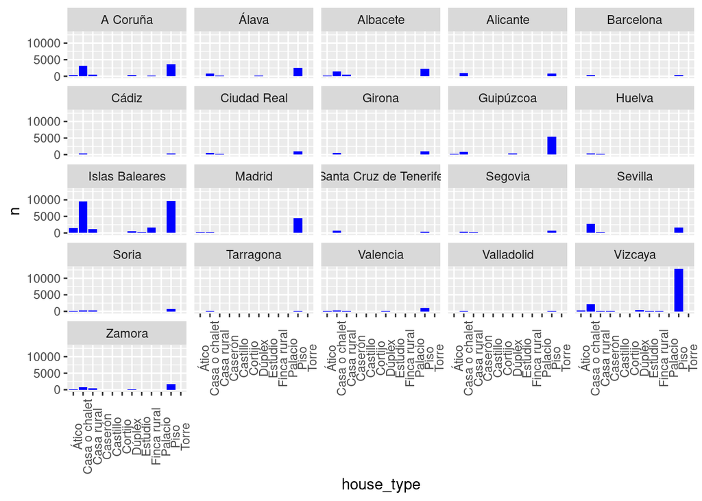

```r
ggplot(data=tabla2, aes(y = n, x=house_type)) + geom_bar(stat = 'identity', fill = 'blue') + facet_wrap(~loc_zone) + theme(axis.text.x= element_text(angle = 90))
```